# PG_Project1

Howard Murray

2024-06-03

# Reproducible Research Project 1

This is an R Markdown document created to submit Peer Graded Course Project 1 in the Coursera Reproducible Research course.

This project called for us to submit the following:  
1. Code for reading in the dataset and/or projcessing the data  
2. Histogram of the total number of steps taken each day  
3. Mean and median number of steps taken each day  
4. Time series plot of the average number of steps taken  
5. The 5-minute interval that, on average, contains the maximum number of steps  
6. Code to describe and show a strategy for imputing missing data  
7. Histogram of the total number of steps taken each day after missing values are imputed  
8. Panel plot comparing the average number of steps taken per 5-minute interval across weekdays and weekends  
9. All of the R code needed to reproduce the results (numbers, plots, etc.) in the report

## Part 1 - Load the dataset in and process it as needed for analysis

```r
library(lubridate)
# Download data file
# Check if file exists, if not, download it.
if (!file.exists("repdata_data_activity.zip")) {
download.file("https://d396qusza40orc.cloudfront.net/repdata%2Fdata%2Factivity.zip", "repdata_data_activity.zip", method = "curl")
}
# Unzip file
unzip("repdata_data_activity.zip")

# Read in dataset
activity <- read.csv("activity.csv", na.strings = "NA")

# Convert date column to date format
activity$date <- ymd(activity$date)

#Add column for the days of the week for the dates in the dataset
day <- weekdays(activity$date)
activity <- cbind(activity, day)

# View the processed dataset
summary(activity)
```

```
##      steps             date               interval          day
##  Min.   :  0.00   Min.   :2012-10-01   Min.   :   0.0   Length:17568
##  1st Qu.:  0.00   1st Qu.:2012-10-16   1st Qu.: 588.8   Class :character
##  Median :  0.00   Median :2012-10-31   Median :1177.5   Mode  :character
##  Mean   : 37.38   Mean   :2012-10-31   Mean   :1177.5
##  3rd Qu.: 12.00   3rd Qu.:2012-11-15   3rd Qu.:1766.2
##  Max.   :806.00   Max.   :2012-11-30   Max.   :2355.0
##  NA's   :2304
```

## Part 2 - What is the mean total of steps taken per day?

For this part of the assignment, we are to create a histogram and compute the number of steps taken per day. We can ignore any missing values.

Here is a histogram of the activity dataset.

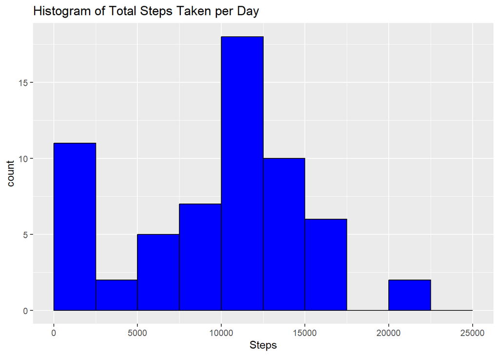

The **mean of the total steps taken per day** is **9354**. The mean was calculated using R Markdown’s inline code feature. I also calculated the mean in a code chunk. See below.

```r
mean(totSteps$Steps)
```

```
## [1] 9354.23
```

The **median of the total steps taken per day** is **10395**. The median was calculated using R Markdown’s inline code feature. I also calculated the median in a code chunk. See below.

```r
median(totSteps$Steps)
```

```
## [1] 10395
```

## Part 3 - What is the average daily activity pattern?

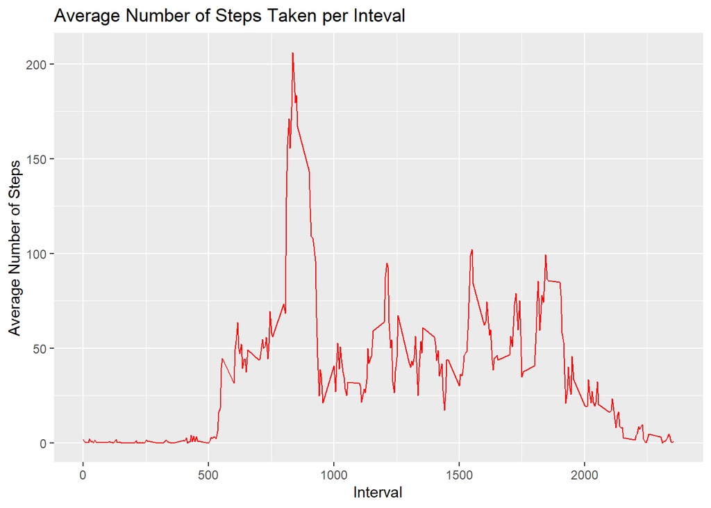

```r
# Compute average steps taken, averaged across all days (y-axis)
totAveDaySteps <- with(activity, aggregate(steps, by = list(interval), mean, na.rm = TRUE))

# change colunn names
names(totAveDaySteps) <- c("Interval", "Average")

# Create a time series plot of Ave number of step per interval
ggplot(totAveDaySteps, aes(Interval, Average)) +
  geom_line(col = "red") +
  labs(x = "Interval", y = "Average Number of Steps", title = "Average Number of Steps Taken per Inteval")
```

**Which 5-minute interval, on average across all the days in the dataset, contains the maximum number of steps?**

```r
# Find the index of the interval with the highest number of steps.
totAveDaySteps[which.max(totAveDaySteps$Average),]$Interval
```

```
## [1] 835
```

## Part 4 - Imputing missing values

**Calculate and report the total number of missing values in the dataset (i.e the total number of rows w ith NAs)**

```r
# Get count of number of rows with NAs entered for steps
sum(is.na(activity$steps))
```

```
## [1] 2304
```

```r
# Compute the average daily steps per interval
imputed.Steps <- totAveDaySteps$Average[match(activity$interval, totAveDaySteps$Interval)]

# Replace missing values with the average for that interval
imputed.activity <- transform(activity, steps = ifelse(is.na(activity$steps), yes = imputed.Steps, no = activity$steps))

# Create new dataframe with aggregated values and imputed data
tot.imputed.activity <- aggregate(steps ~ date, imputed.activity, sum)
names(tot.imputed.activity) <- c("date", "Daily_Steps")

# Check for missing values
sum(is.na(tot.imputed.activity$Daily_Steps))
```

```
## [1] 0
```

**Make a histogram of the total number of steps taken each day and Calculate and report the mean and median total number of steps taken per day. Do these values differ from the estimates from the first part of the assignment? What is the impact of imputing missing data on the estimates of the total daily number of steps?**

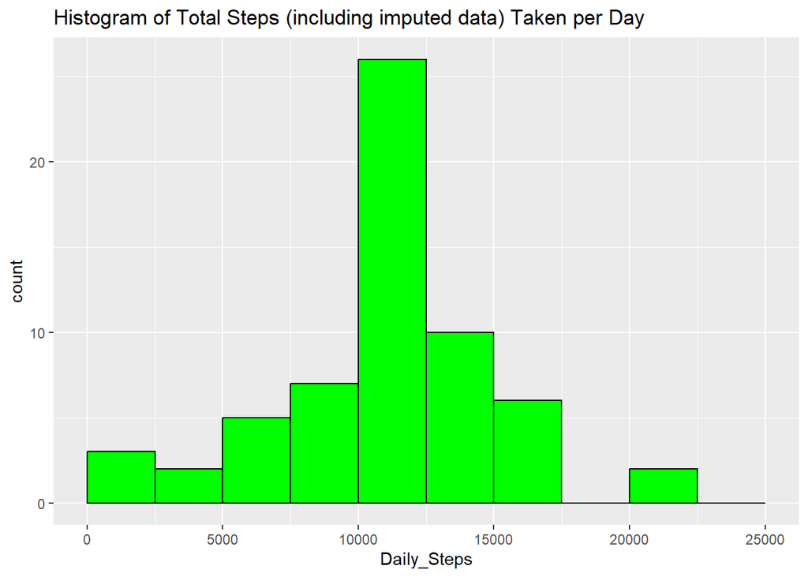

Compute the **mean total number of steps** taken per day.

```r
mean(tot.imputed.activity$Daily_Steps)
```

```
## [1] 10766.19
```

Compute the **median total number of steps** taken per day.

```r
median(tot.imputed.activity$Daily_Steps)
```

```
## [1] 10766.19
```

## Part 5 - Are there differences in activity patterns between weekdays and weekends?

**Create a new factor variable in the dataset with two levels - “weekday” and “weekend” indicating whether a given date is a weekday or a weekend day.**

```r
activity$day.type <- sapply(activity$date, function(x){
  if(weekdays(x) == "Saturday"| weekdays(x) == "Sunday")
  {y <- "Weekend"}
  else {y <- "Weekday"}
  y
})
```

**Make a panel plot containing a time series plot(i.e. type = “l”) of the 5-minute interval(x-axis) and the average number of steps taken, averaged across all weekday days or weekend days (y-axis). See the README file in the README file in the GitHub repository to see and example of what this plot should look like using simulated data.**

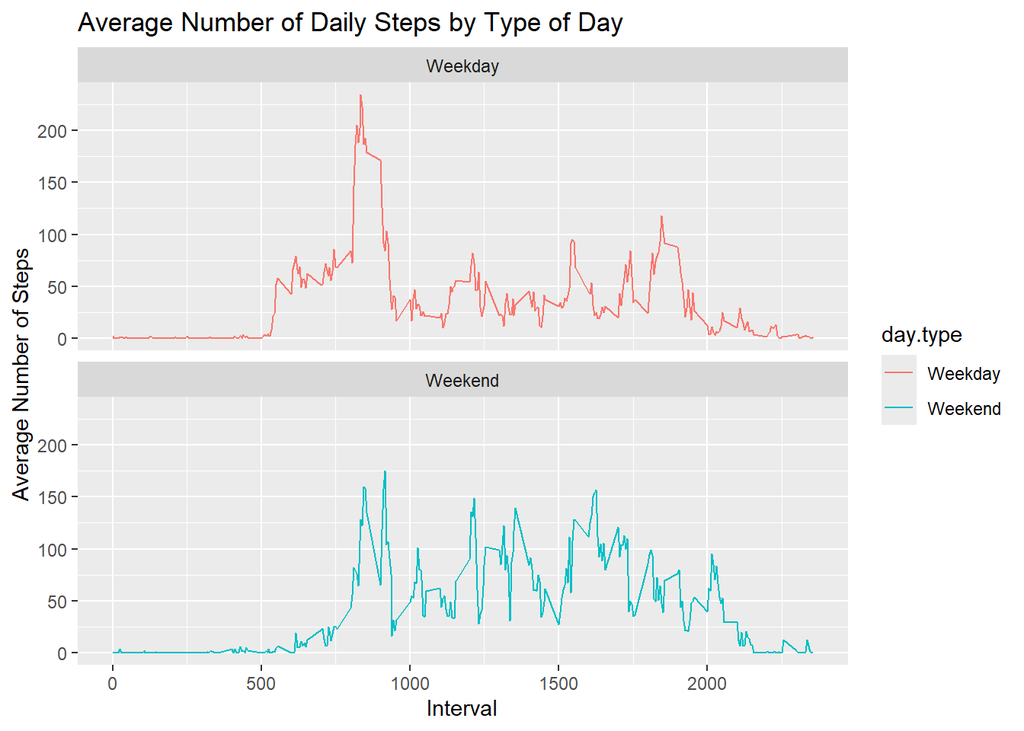

```r
# Formulate dataset to be plotted
activity.by.daytype <- aggregate(steps ~ interval + day.type, activity, mean, na.rm = TRUE)

# Create the panel plot using facets
ggplot(activity.by.daytype, aes(x = interval, y = steps, color = day.type)) +
  geom_line() +
  labs(x = "Interval", y = "Average Number of Steps", title = "Average Number of Daily Steps by Type of Day") +
  facet_wrap(~day.type, ncol = 1, nrow = 2)
```